# Untitled

Gómez Jiménez Aaron Mauricio

2023-04-06

Usted invierte dinero en la compra de una acción. Para saber qué tan viable es su inversión, ha decidido hacer un análisis de serie de tiempo. Este tipo de análisis se utiliza para examinar los datos históricos y predecir futuros cambios en el valor de una inversión. Antes de invertir, es importante informarse y evaluar su disposición al riesgo y objetivos, así como hacer su perfil de inversionista. También es fundamental conocer los fundamentos de las inversiones y la rentabilidad esperada. Además, existen diversas metodologías que pueden ayudar a desarrollar estrategias efectivas para la inversión.

Para su tarea busquen en Yahoo finanzas una acción que les llame su atención para su análisis. Yahoo finanzas es una de las principales páginas en la que usted podrá consultar información financiera, en ella además le permitirá ver gráficamente los datos y lo más importante descargar los datos en formato csv. Descargue los datos históricos del **1 de enero de 2001** al **30 Junio de 2020**, y en frecuencia indique periodicidad mensual, guarde estos datos en su carpeta de trabajo e impórtelos en R.

Con base a dichos valores realice:

**1.Descargue e importe los datos en R y con ellos convierta el vector de precios a un objeto de series de tiempo y vea el comportamiento de sus datos, es decir calcule la media, moda, cuartiles, máximos, mínimos y varianza. Haga una gráfica de caja para ver visualmente estos resultados.**

Nuestro interés está en ver la posibilidad de invertir en las acciones de [*CEMEX*](https://www.cemexmexico.com/) una empresa ligada al ámbito de la construcción que se autodenomina ser líder en la venta y producción de Cemento y otros materiales. Para saber si es una buena opción hacer está inversión revisaremos los datos históricos desde el 1 de enero de 2001 al 30 de junio de 2020, usando algunos comandos y librerías de R extraeremos los datos desde [Yahoo! Finanzas](https://es-us.finanzas.yahoo.com/), tal como se muestra en el siguiente código:

```r
getSymbols("CX", src = "yahoo", from = "2001-01-01", to = "2020-06-30",
           periodicity= "monthly")
base <- CX[,6] # para solo usar la columna de los precios de cierre ajustados
ts_base <- ts(base, start=2001, frequency = 12) # creamos el objeto de series de tiempo
```

Una vez que tenemos la base y el objeto series de tiempo comenzamos a hacer un análisis del comportamiento de los datos obteniendo algunos datos interesantes, que se pueden ver resumidos en la Tabla 1:

|  | Valores de la acción |
| --- | --- |
| Media | 9.703 |
| Moda* | 7.463 |
| Mínimo | 2.120 |
| Cuartil 0.25 | 6.322 |
| Mediana | 7.961 |
| Cuartil 0.75 | 10.284 |
| Máximo | 27.697 |
| Varianza | 31.298 |

Note:  
* = Es el valor de la locación estimada de la moda

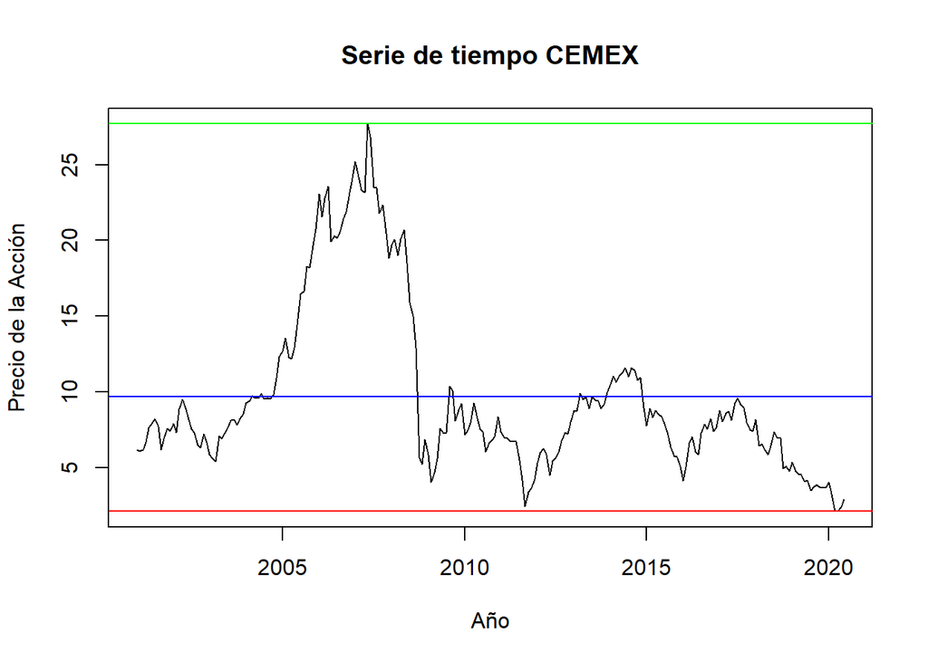

Media, minimo y maximo de la acción CEMEX

Como ya analizamos en valor promedio de la acción es de *9.703*, al graficar el minimo observamos que se alcanza en marzo de 2020 con valor al cierre ajustado de *2.120*, que como se puede inferir se debio a la pandemia ya que al entrar en confinamiento la producción y venta de cemento se vio afectada, despues de tocar su minimo desde 2001, la acción se revalua y empieza a subir de precio, observamos que su mejor precio fue en mayo de 2007 con un valor de 27.697, despues tuvo fluctuaciones y pendientes negativas que coinciden con los años de la crisis de 2008, la gripe porcina 2009, la recesión de 2012, una caida en 2016, y despues una caida alcanzando su minimo hasta la pandemia de COVID-19.

Además a través de un gráfico de caja se puede ver el resumen de estas medidas, tal como se muestra en la Figura 1:

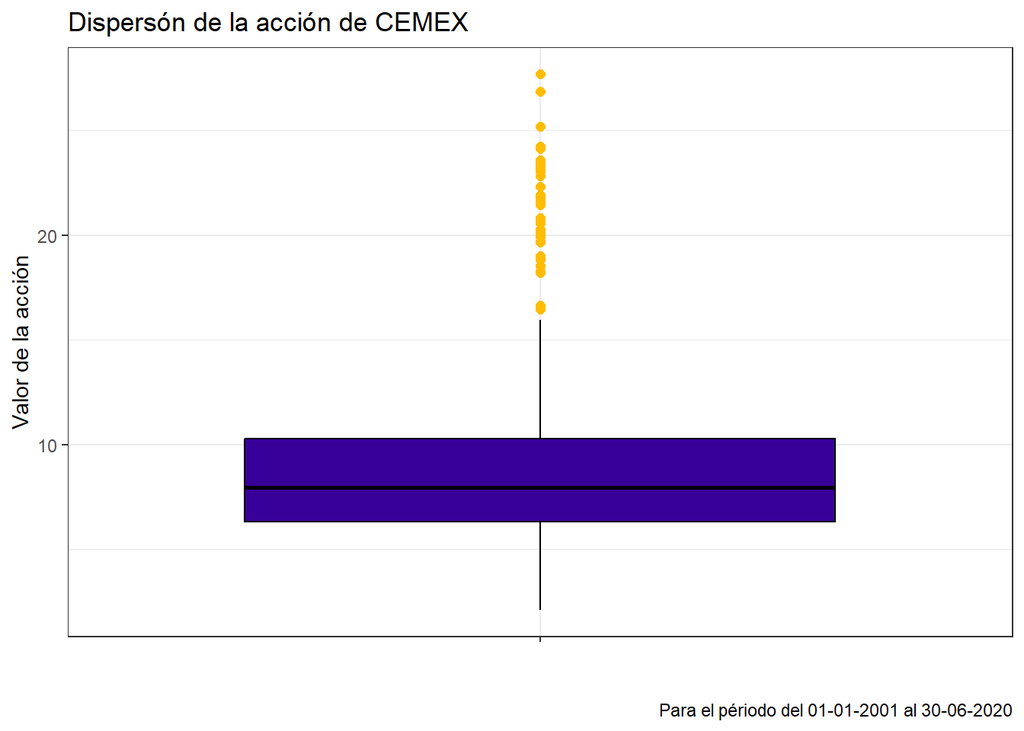

Boxplot de la acción de CEMEX

Graficamente podemos observar que existen muchos outliers, y hay 20 puntos de varianza con la media y el maximo, eso nos indica que esta muy lejos de el valor que llego a tener la acción.

**2.Haga un análisis de sus datos, determinar si hay tendencias crecientes, decrecientes y periodicidad.**

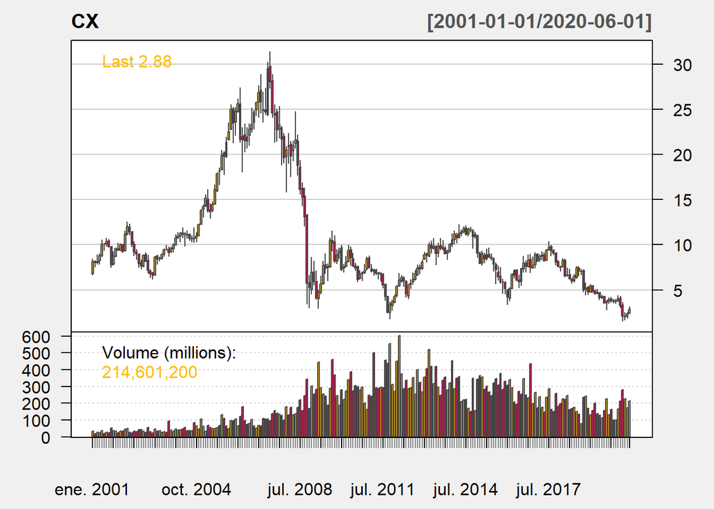

Gráfico Financiero para la acción CX

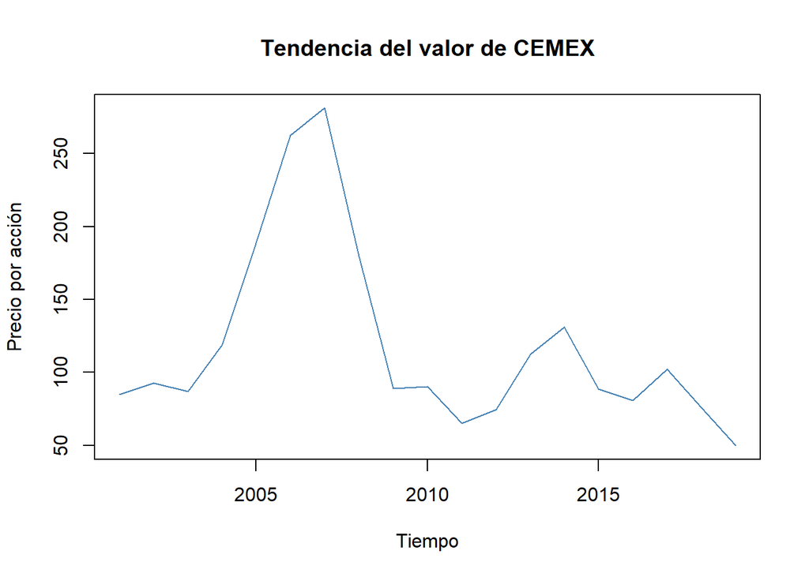

Gráfico de Tendencia CEMEX

Como podemos observar no se ven tendencias a lo largo de los ultimos años, mas bien se ve que no existe tendencias mas allá de las crisis ya descritas, tampoco de observa periodicidad.

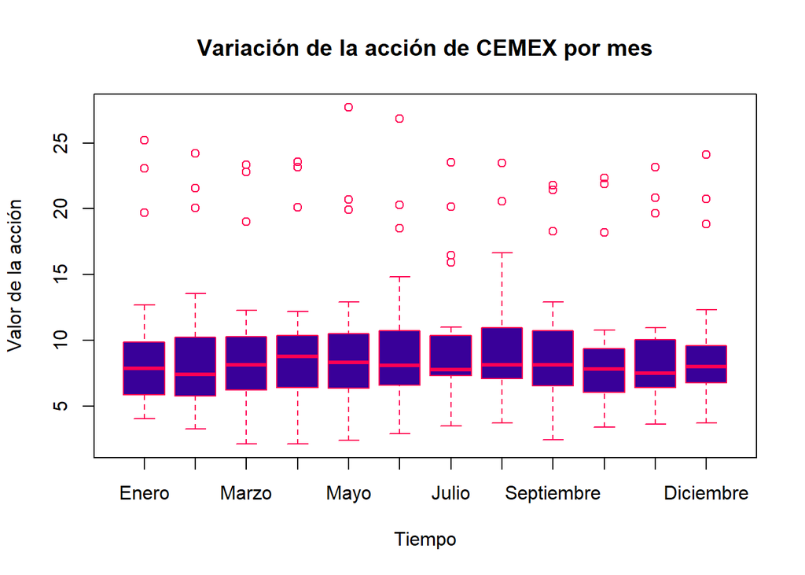

Boxplot para cada mes para la acción CEMEX

En los boxplots mensuales podemos ver casi una recta constante cerca de la media del precio aunque con muchos outliers.

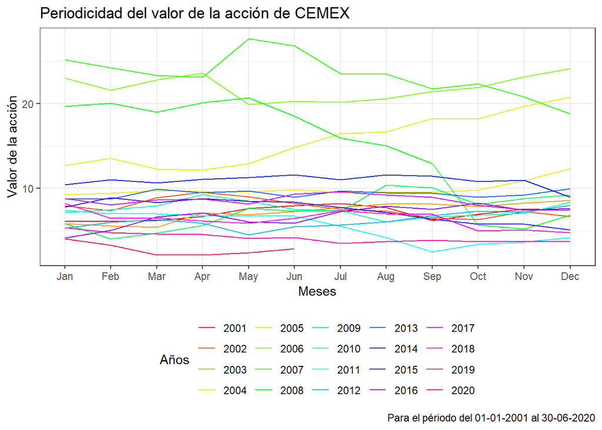

Gráfico de líneas para estudiar periodicidad de la acción de CX

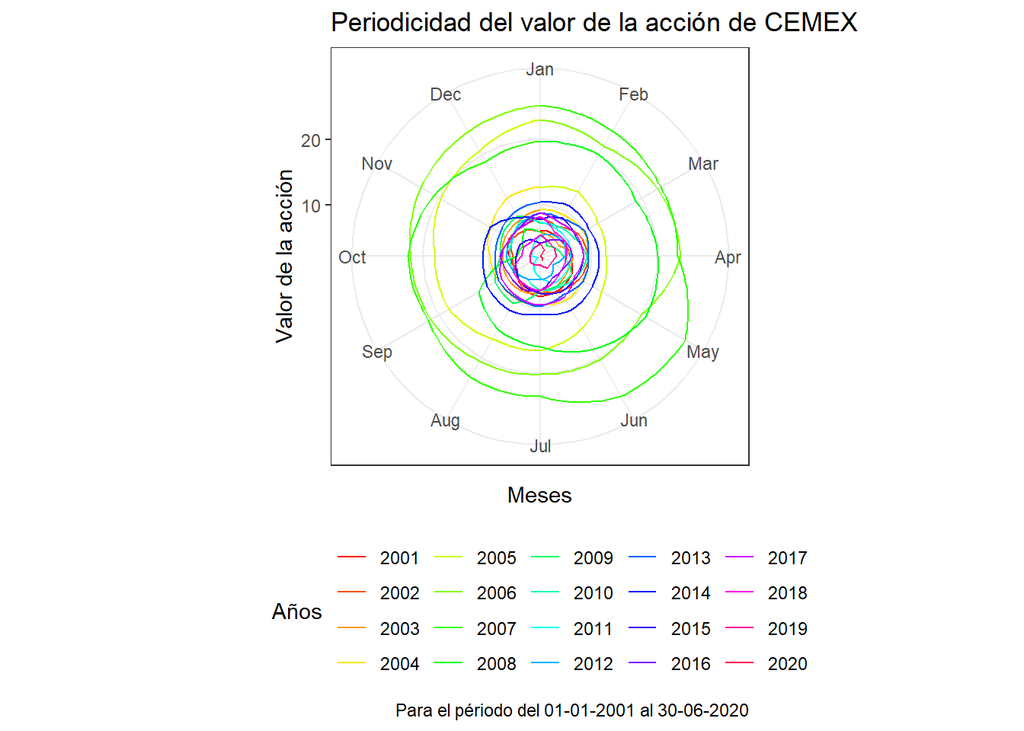

```r
ggseasonplot(ts_base,
           polar=T,
           main="Periodicidad del valor de la acción de CEMEX")+
  labs(x="Meses",
       y= "Valor de la acción",
       caption = "Para el périodo del 01-01-2001 al 30-06-2020",
       color = "Años")+
  # geom_text(aes(label = year))+
  scale_color_manual(values = rainbow(20))+
  theme_bw()+
  theme(legend.position = "bottom")
```

Es mas facil observar en esta grafica que no existe estacionalidad ni periodicidad, ya que cada año la grafica cambia mucho en contraste con los otros años.

**3.Realice una gráfica de la serie de tiempo usando las metodologías vistas en clases (ggplot2,plot y xts)**

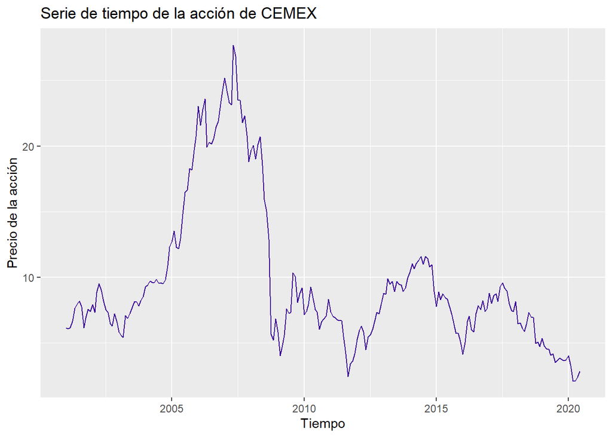

Serie de Tiempo de la acción de CEMEX con ggplot2

Esta es la grafica obtenida al usar la libreria ggplot2, que para lo cual como ya vimos necesitamos hacer una base de datos.

Ahora, usando la serie de tiempo que ya creamos de nuestros datos podemos usar la función plot como se observa a continuación.

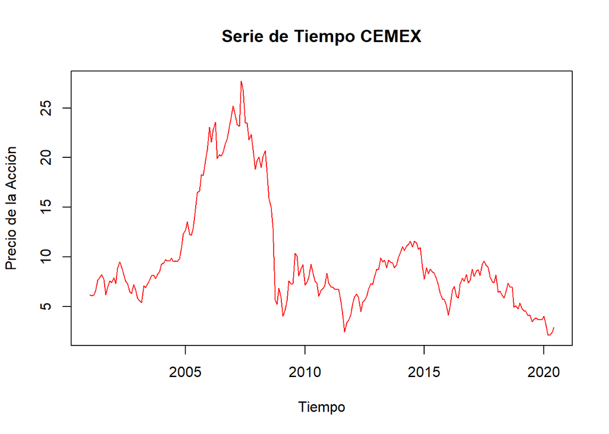

Serie de Tiempo de la acción de CEMEX con plot

Otra forma vista para graficar es usando la libreria xts:

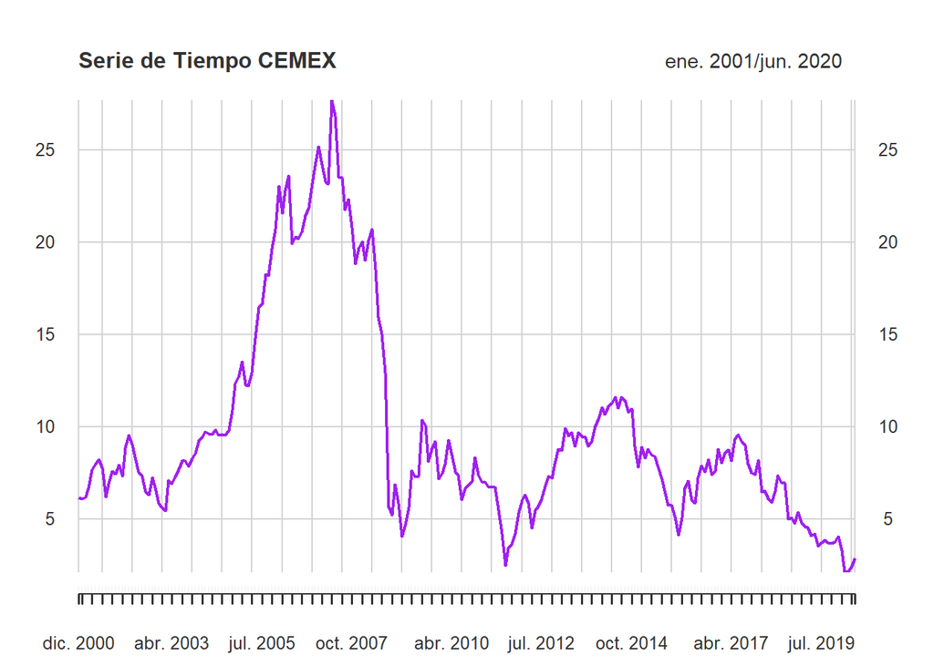

Serie de Tiempo de la acción de CEMEX con xts

Esta opción nos agrega lineas verticales que nos hacen mas fácil la interpretación de los datos, ya que es mas fácil ubicar la temporalidad de la serie.

**4.Realiza las siguientes suavizaciones:** **Suavización de promedios móviles simple (PS) de orden 2 y 10.**

```r
p.mov.2 = ma(ts_base, order = 2)
p.mov.10 = ma(ts_base, order = 10)
```

**Suavización de promedios móviles ponderados (PPM) de orden 4 con los pesos ($0.5, 0.2, 0.2, 0.1$) para ($x_t, x_{t−1}, x_{t−2}, x_{t−3}$) y otro modelo (PPM) de orden 12 seleccionando ustedes mismos los pesos y mencionado el porque de esos pesos.**

```r
pesos.b1 <- c(0.5,0.2,0.2,0.1)
p.mov.pond.4 <- stats::filter(ts_base, pesos.b1, sides=1)

ts <- c(ts_base, rep(0,6))
ts_matrix <- matrix(ts, ncol = 12, byrow = T)
suma <- sum(colMeans(ts_matrix))
pesos.b2 <- round(colMeans(ts_matrix)/suma,4)

p.mov.pond.12 <- stats::filter(ts_base, pesos.b2, sides=1)
```

Para obtener nuestros pesos, al notar que estamos tomando en cuenta el año anterior, decidimos hacer el promedio historico de cada mes y así obtuvimos el valor de cada alfa para cada mes, de esta forma intentamos minimizar la varianza a corto plazo ya que nuestros alfas son pequeños.

**Suavización de promedios móviles simples centrados (PSC) de orden 2 y 10.**

```r
p.mov.2.c = ma(ts_base, order = 2, centre = TRUE)
p.mov.10.c = ma(ts_base, order = 10, centre = TRUE)
```

**Suavización exponencial simple con $\alpha = 0.01, \alpha = 0.5, \alpha = 0.99$, ¿Cuál es el papel de $\alpha$ en la estimación de valores pronostico?**

```r
ts.base.sua_001 = ses(ts_base, alpha=0.01, initial = 'simple')
ts.base.sua_05 = ses(ts_base, alpha=0.5, initial = 'simple')
ts.base.sua_099 = ses(ts_base, alpha=0.99, initial = 'simple')
```

**Suavización Holt, con $\alpha = 0.5 y \beta = 0.2, \beta = 0.8$ ¿Cuál es el papel de $\beta$ en la estimación de valores pronostico?**

```r
ts.holt_0502 = Holt(ts_base, alpha = 0.5, beta=0.2)
```

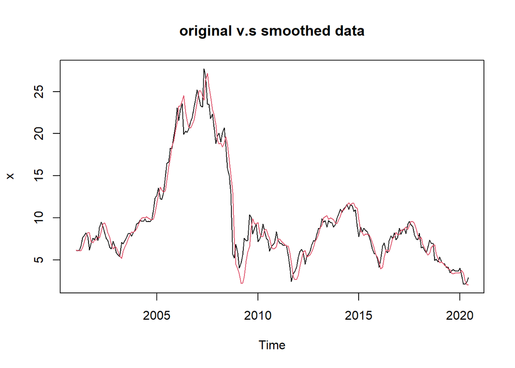

```r
ts.holt_0508 = Holt(ts_base, alpha = 0.5, beta=0.8)
```

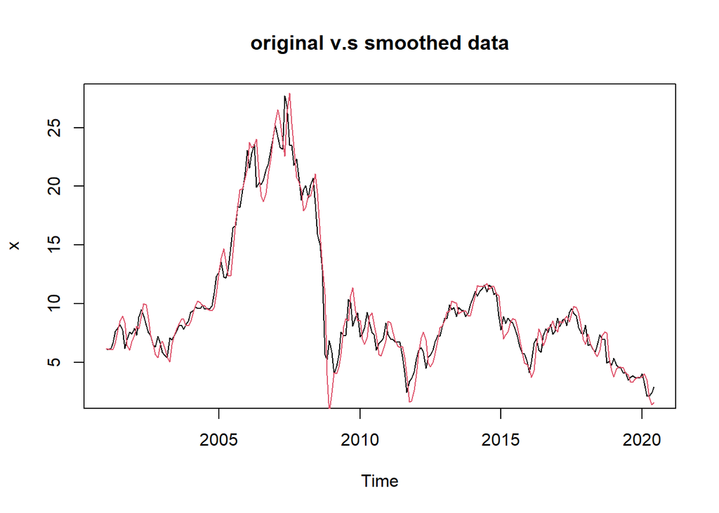

El papel de las betas es suavizar o exponenciar los cambios en las tendencias, una beta pequeña suaviza las tendencias recientes, es decir les da menor peso.

**Suavización Holt-Winters, con $\alpha = 0.5 y \beta = 0.2, \gamma = 0.8$ y otro modelo Holt-Winters con una selección automática de R.**

```r
hw.ts.1 = hw(ts_base, h=12,optim.start = c(0.5,0.2,0.8))
hw.ts.2 = hw(ts_base, h=12, seasonal='additive')
```

Notemos que en este modelo el valor de gamma suaviza la estacionalidad.

**5.Cada inciso del punto anterior tiene dos o tres modelo del mismo tipo, así que una misma gráfica muestra los resultados junto con la serie original por modelo.**

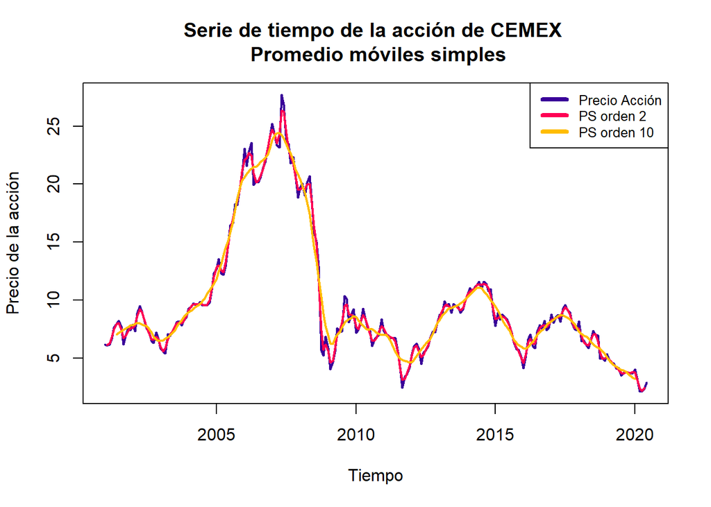

Serie de Tiempo de la acción de CEMEX junto con el ajuste de Promedio móviles simples

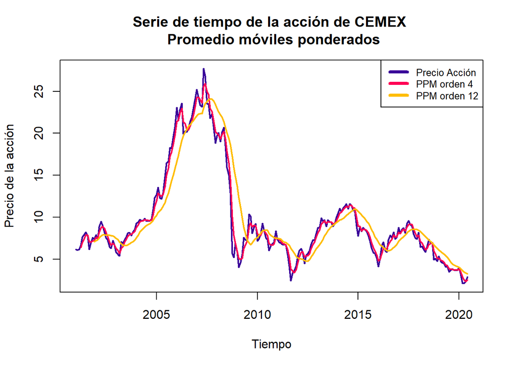

Serie de Tiempo de la acción de CEMEX junto con el ajuste de Promedio móviles ponderados

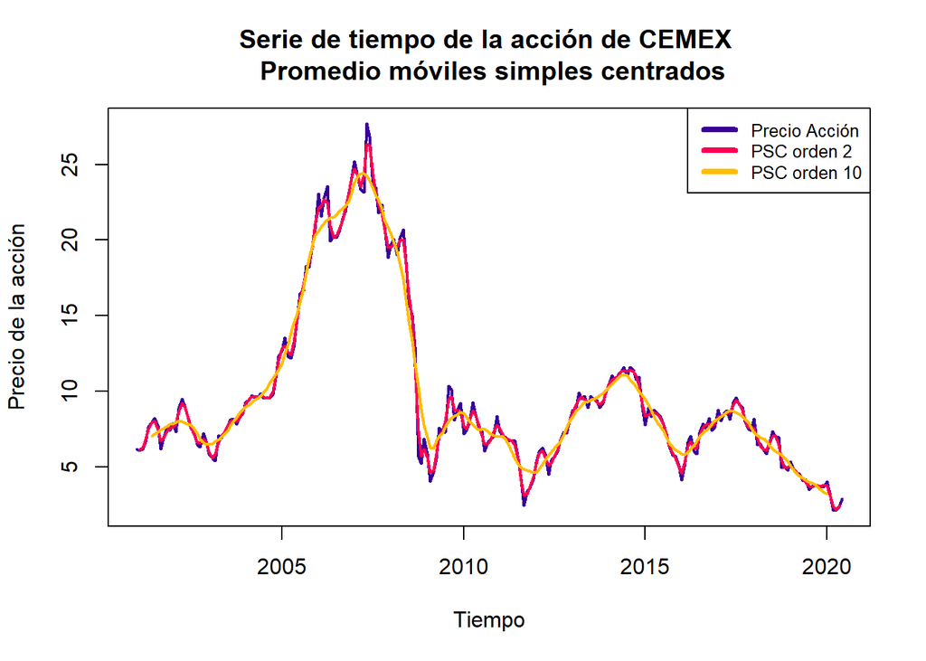

Serie de Tiempo de la acción de CEMEX junto con el ajuste de Promedio móviles simples centrados

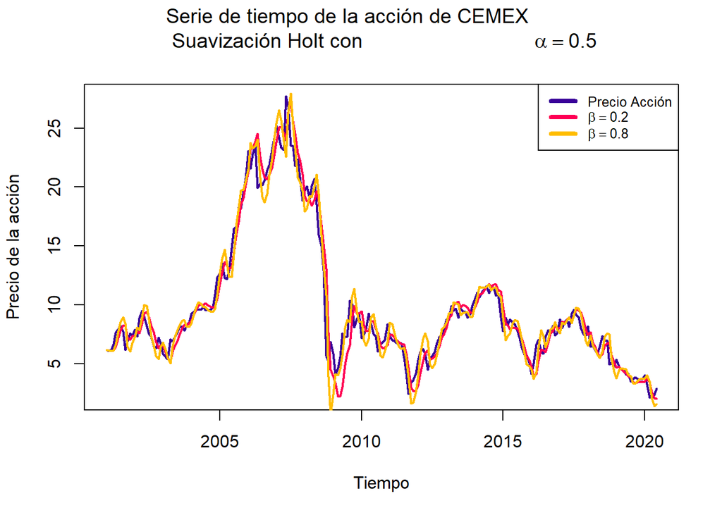

Serie de Tiempo de la acción de CEMEX junto con la suavización Holt

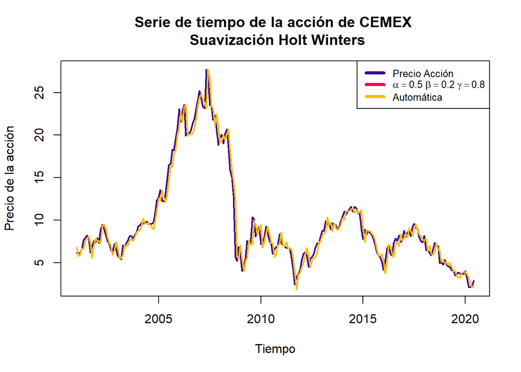

Serie de Tiempo de la acción de CEMEX junto con la suavización Holt-Winters

**7.Utilizar la autocorrelación para determinar si hay patrones en los residuos de una serie de tiempo.**

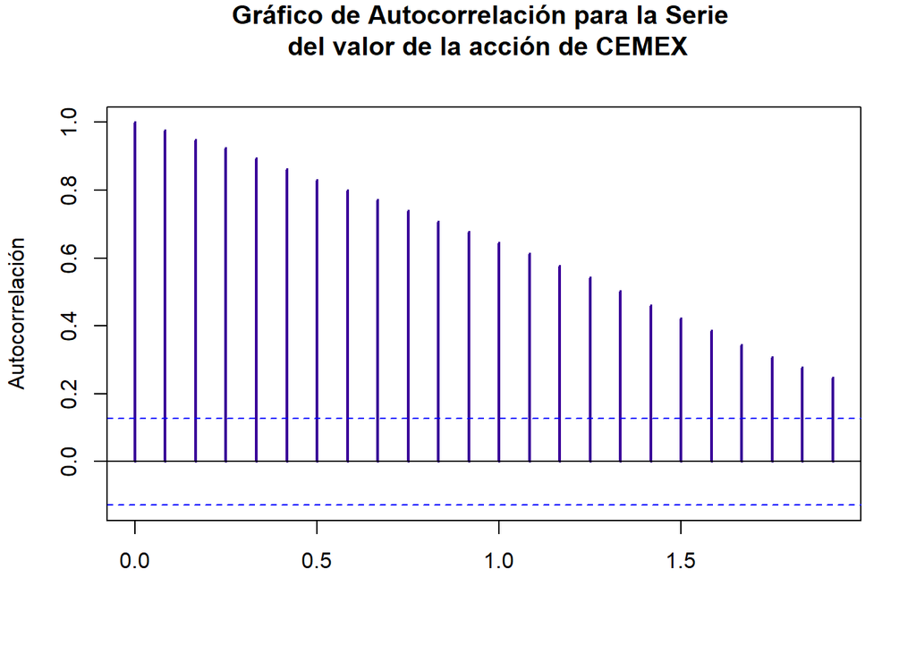

Gráfico de Autocorrelación

**9.Demuestra que si una serie de tiempo es estacionaria en media y varianza, entonces su autocorrelación es**

$$\rho(h) = Corr(x_t, x_{t+h}) =
\dfrac{E[x_t, x_{t+h}] − \mu}{\sigma^2}$$
**10.Demuestra mediante inducción que en el suavizado exponencial esta expresión es válida**

$$\hat{x}_{t+1} = ax_t + (1 − α)\hat{x}_t$$